# Post COVID-19 vaccination menstrual disturbances in the UK

This script allows to reproduce the analysis of reports of menstrual disturbances following post-COVID-19 vaccination.

# 1. Data preparation

## Load packages

```r
# Ensures the package "pacman" is installed
if (!require("pacman")) install.packages("pacman")
# Packages available from CRAN
##############################
library(pacman)


## Load
pacman::p_load(
     dplyr,
     gtsummary,
     rio,         # import/export
     here,        # file locator
     purrr,       # iteration
     tidyverse,
     flextable,
     ggplot2,
     forcats,
     kableExtra,
     flextable,
     Hmisc,
     pbapply,
     mice,
     GGally,
     effects,
     gridExtra,
     grid,
     lattice,
     summarytools,  # descriptive
     gtsummary      # tables
)
```

## Load data

```r
# list of 5 imputed datasets
multfin<-import(here("data","data_covid19vaccine_menstrualcycles_uk_names.Rda")) # imputed list

# original data used for imputation
dataor<-import(here("data","data_covid19vaccine_menstrualcycles_uk_original.Rda")) # original dataset of vaccinated people


# describe the data
#view(dfSummary(dataor) #
```

# 2. Descriptive Table

```r
# create tbl objects
theme_gtsummary_journal(journal = "jama")
theme_gtsummary_compact()
tbl<-
  tbl_summary(
  select(dataor , age, edu_group,liveuk,ethnic_group,income_before, smoke_before,maritalstatus, maritalstatus, gender, nbdeliveries,contra_current_groupall, covid_group,covid_tested, vaccinated, vaccine_type,vaccine_timing),
 label = list(age ~ "Age",
            edu_group~ "Education level",
            liveuk~ "Place of residence",
            ethnic_group~ "Ethnic group",
            income_before~ "Net income before pandemic",
            smoke_before~ "Smoking status before pandemic",
            maritalstatus~ "Marital status",
            gender~ "Gender",
            nbdeliveries~ "Number of deliveries",
            contra_current_groupall~ "Contraceptive use at the time of the survey",
            covid_group~ "Self-reported COVID status",
            covid_tested~ "COVID status based on testing",
            vaccinated~ "Number of vaccination shots",
            vaccine_type~ "Vaccine type",
            vaccine_timing~ "Timing of 1st dose"
           ))

# beautify
tblbest<-tbl %>%
  modify_caption("Table 1. Summary of the sample characteristics") %>%
  bold_labels()

# convert gtsummary object into flextable to export to word
tblbest%>%
  as_flex_table()%>%
  flextable::save_as_docx(path = "Table1.docx")
```

# 3. Logistic regression

## Univariable analyses

### Models and output table

```r
# set global R options
pboptions(type = "timer", char = "=") # initialize progress bar

# set list of exposures to test
exposures <- c(
    Cs(
        age,
        ethnic_group,
        med_lastyr_binary_num,
        vit_lastyr_binary_num,
        maritalstatus,
        gender,
        bmi_group,
        physact_before,
        income_before,
        smoke_before,
        contra_current_groupall,
        cyclelength_before_group,
        period_lengh_before_group,
        heavyperiod_before,
        cycle_irreg_before,
        nbdeliveries,
        vaccine_type,
        vaccine_timing,
        covid_group,
        covid_tested,
        vaccinated,
        changesmenses_num,
        lifesatchanges,
        disease_before_endometriosis_num,
        disease_before_pcos_num,
        disease_before_underthyroid_num,
        disease_before_overthyroid_num,
        disease_before_uterpolyp_num,
        disease_before_uterfibroid_num,
        disease_before_intercystitis_num,
        disease_before_eatingdisord_num,
        liveuk,
        edu_group

    )
)

### Univariable ------------------------------------------------------------

## model function
models <- function(x) {
    lapply(multfin, function(y)
        glm(as.formula(
            paste0(
                "vaccine_changescycle_binary ~  ",
                x

            )
        ), data = y, model=TRUE, family=binomial())
    )
}

## run logistic models
models_univariate <- as.list(seq(1,length(exposures))) # create list to store model results
library(pbapply)
models_univariate <- pblapply(exposures, models)




### Pool -------------------------------------------------------------------

pool_univariate <- as.list(seq(1,length(exposures))) # create list to store pool results

# run pool
for(j in seq_along(exposures)) {
    pool_univariate[[j]] <- pool(models_univariate[[j]])
}



### p values under FDR---------------------------------------------------------------

library(data.table)
smry <-lapply(pool_univariate,
             summary,
              conf.int = TRUE,
            conf.level = 0.95)
all_models <- rbindlist(smry)



# this is the FDR p values
all_models$q.value <- p.adjust(all_models$p.value,method = "BH")



## Table with adjusted p values--------------------------------------------------

all_models2<-all_models%>% filter (term!="(Intercept)")# to remove the intercept from the output
row<- which(all_models2$q.value<0.05) # to highlight in red those which are significant
library(kableExtra)

# change names
names(all_models2)<-c("term","estimate","std.error","statistic","df","p.value","lowCI","highCI","q.value")

# create the table
table<-all_models2%>% filter (term!="(Intercept)")%>%
  mutate(OR=exp(estimate))%>%
  mutate(ORConf.low=exp(lowCI))%>%
  mutate(ORConf.high=exp(highCI))%>%
  select(term,OR,ORConf.low,ORConf.high,statistic,df,p.value, q.value) %>%
  kbl(caption = "Univariable models adjusted p-values") %>%
  kable_paper(bootstrap_options = "striped", full_width = F)%>%
  row_spec(row=c(row), bold = T, color = "white", background = "#D7261E")%>%
  pack_rows("Age", 1,1) %>%
  pack_rows("Ethnic Group", 2,2) %>%
    pack_rows("Medication Use", 3,3) %>%
      pack_rows("Vitamins Use", 4,4) %>%
  pack_rows("Marital status", 5, 6) %>%
  pack_rows("Gender", 7,7) %>%
  pack_rows("BMI", 8, 10) %>%
   pack_rows("Physical activity", 11, 14) %>%
  pack_rows("Income", 15, 19) %>%
    pack_rows("Smoking", 20, 21) %>%
    pack_rows("Contraception", 22, 26) %>%
    pack_rows("Cycle length", 27, 29) %>%
     pack_rows("Period length", 30, 35) %>%
  pack_rows("Heavy Bleeding", 36,36) %>%
  pack_rows("Irregular cycles", 37, 39) %>%
   pack_rows("Nb deliveries", 40, 42) %>%
     pack_rows("Vaccine type", 43,43) %>%
   pack_rows("Vaccine timing", 44, 46) %>%
    pack_rows("COVID group", 47,48) %>%
      pack_rows("COVID tested", 49, 50) %>%
        pack_rows("Nb shots", 51, 51) %>%
    pack_rows("Changes in menstrual cycles over the last year", 52,52) %>%
      pack_rows("Life satisfaction changes", 53, 53) %>%
   pack_rows("Endometriosis", 54, 54) %>%
   pack_rows("PCOS", 55, 55) %>%
   pack_rows("Underactive Thyroid", 56, 56) %>%
   pack_rows("Overactive Thyroid", 57, 57) %>%
   pack_rows("Uterine Polyps", 58, 58) %>%
   pack_rows("Uterine Fibroids", 59, 59) %>%
   pack_rows("Inter cystitis", 60, 60) %>%
   pack_rows("Eating disorders", 61, 61) %>%
  pack_rows("Country of residence", 62, 64) %>%
  pack_rows("Education",65,67)%>%
  kable_styling(full_width = T)

# save
table%>%
   save_kable("TableSI_univariable.html")

# print
table
```

Univariable models adjusted p-values

| term | OR | ORConf.low | ORConf.high | statistic | df | p.value | q.value |
| --- | --- | --- | --- | --- | --- | --- | --- |
| **Age** |  |  |  |  |  |  |  |
| age | 0.9759262 | 0.9097953 | 1.0468640 | -0.6808461 | 4737.95128 | 0.4960021 | 0.6888919 |
| **Ethnic Group** |  |  |  |  |  |  |  |
| ethnic_groupOther | 1.3331996 | 0.9876546 | 1.7996385 | 1.8797153 | 2507.32088 | 0.0602628 | 0.1229852 |
| **Medication Use** |  |  |  |  |  |  |  |
| med_lastyr_binary_num | 0.9548433 | 0.8295051 | 1.0991201 | -0.6437867 | 4181.96730 | 0.5197491 | 0.7119850 |
| **Vitamins Use** |  |  |  |  |  |  |  |
| vit_lastyr_binary_num | 0.9122010 | 0.7838712 | 1.0615400 | -1.1885974 | 2199.73029 | 0.2347264 | 0.3912107 |
| **Marital status** |  |  |  |  |  |  |  |
| maritalstatuswidowedsep | 1.0319126 | 0.7807659 | 1.3638450 | 0.2208473 | 3291.35419 | 0.8252250 | 0.9595640 |
| maritalstatusNevermarried_partnered | 1.0668493 | 0.9203778 | 1.2366305 | 0.8591217 | 3264.59666 | 0.3903364 | 0.5825917 |
| **Gender** |  |  |  |  |  |  |  |
| genderOther | 0.7125412 | 0.3184975 | 1.5940942 | -0.8251445 | 5046.47300 | 0.4093286 | 0.5932298 |
| **BMI** |  |  |  |  |  |  |  |
| bmi_groupObese | 1.1702756 | 0.9897207 | 1.3837692 | 1.8399075 | 2798.93747 | 0.0658876 | 0.1317753 |
| bmi_groupOverweight | 1.1176649 | 0.9111067 | 1.3710521 | 1.0797619 | 102.46443 | 0.2827833 | 0.4635792 |
| bmi_groupUnderweight | 1.1762819 | 0.5802389 | 2.3846023 | 0.4504119 | 4970.98003 | 0.6524331 | 0.8473157 |
| **Physical activity** |  |  |  |  |  |  |  |
| physact_before60-90 minutes | 1.1041876 | 0.9100860 | 1.3396869 | 1.0050469 | 4700.48257 | 0.3149260 | 0.4905953 |
| physact_before90-120 minutes | 0.9965928 | 0.7643396 | 1.2994187 | -0.0252181 | 4901.25131 | 0.9798820 | 0.9899841 |
| physact_beforeLess than 30 minutes | 1.2142532 | 0.9998185 | 1.4746786 | 1.9586293 | 4777.31467 | 0.0502143 | 0.1091616 |
| physact_beforeMore than 120 minutes | 1.2374199 | 0.9913816 | 1.5445192 | 1.8840686 | 3607.30012 | 0.0596360 | 0.1229852 |
| **Income** |  |  |  |  |  |  |  |
| income_beforeBetween £13,682 and £22,140 | 1.2638617 | 0.9798248 | 1.6302369 | 1.8051138 | 1050.65048 | 0.0713431 | 0.1398884 |
| income_beforeBetween £22,140 and £29,254 | 1.1616394 | 0.8695609 | 1.5518246 | 1.0269188 | 96.50687 | 0.3070258 | 0.4873425 |
| income_beforeBetween £39,397 and £76,144 | 1.1054744 | 0.8563050 | 1.4271475 | 0.7874903 | 52.97457 | 0.4345043 | 0.6207204 |
| income_beforeLess than £13,682 | 1.2160668 | 0.9093990 | 1.6261491 | 1.3268003 | 217.29820 | 0.1859673 | 0.3286452 |
| income_beforeMore than £76,144 | 1.2066089 | 0.8899948 | 1.6358580 | 1.2181879 | 169.23420 | 0.2248482 | 0.3810986 |
| **Smoking** |  |  |  |  |  |  |  |
| smoke_beforePast smoker | 1.0042927 | 0.8469667 | 1.1908423 | 0.0492877 | 5020.74659 | 0.9606920 | 0.9899841 |

[output cut: 70 more lines]

We found that smoking behaviour (current smoker), contraceptive type, COVID-19 history and cycle changes over the last year are associated with the odds of reporting menstrual cycles changes.

### AUC

Now we investigate the discriminative utility of each model by computing the AUC and drawing AUC-ROC curves.

```r
library(pROC)
#make this example reproducible
set.seed(1)
#Use 70% of dataset as training set and remaining 30% as testing set
train_list<-list()
test_list<-list()
sample_list<-list()

 for (i in (1:5)){
sample_list[[i]] <-  sample(c(TRUE, FALSE), nrow(multfin[[i]]), replace=TRUE, prob=c(0.7,0.3))
 }
#
 for (i in (1:5)){
train_list[[i]] <- multfin[[i]][sample_list[[i]], ]
test_list[[i]] <- multfin[[i]][!sample_list[[i]], ]
}
#


## model function
modelstrain <- function(x) {
    lapply(train_list, function(y)
        glm(as.formula(
            paste0(
                "vaccine_changescycle_binary ~  ",
                x

            )
        ), data = y, model=TRUE, family=binomial())
    )
}


## run logistic models
model_list <- as.list(seq(1,length(exposures))) # create list to store model results
model_list <- pblapply(exposures, modelstrain)



# Calculate probability of default for each individual in test dataset
predicted_list<-list()
z<-0

for (i in (1:length(exposures))){
  for (j in (1:5)){
    z<-z+1
predicted_list[[z]] <- predict(model_list[[i]][[j]], test_list[[j]], type="response")
  }
}


# Calculate AUC
z<-0
auc_list<-list()
for (i in (1:length(exposures))){
for (i in (1:5)){
     z<-z+1
auc_list[[z]]<-auc(test_list[[i]]$vaccine_changescycle_binary, predicted_list[[z]] )
}
}

# Matrix of AUC
# Unlist
ulist<-unlist(auc_list)

# Create vector of names
names<-NULL
for (i in (1:33)){
newnames<-c(rep(exposures[i],5))
names<-c(names,newnames)
}

matauc<-as.data.frame(cbind(names,as.numeric(ulist)))

# group means
library(plyr)
mu <- ddply(matauc, "names", summarise, mean = mean(ulist))
newdat<-tapply(ulist, names,max,na.rm=T)


# load the library
library(forcats)

# Reorder following the value of another column:
aucplot<-matauc %>%
  mutate(names = fct_reorder(names, ulist)) %>%
  ggplot( aes(x=names, y=ulist))+
    geom_point( size=2, color="orange") +
    coord_flip() +
    xlab("") +
    theme_bw()

pdf(file="AUC_univariable_models.pdf")
aucplot
dev.off()
```

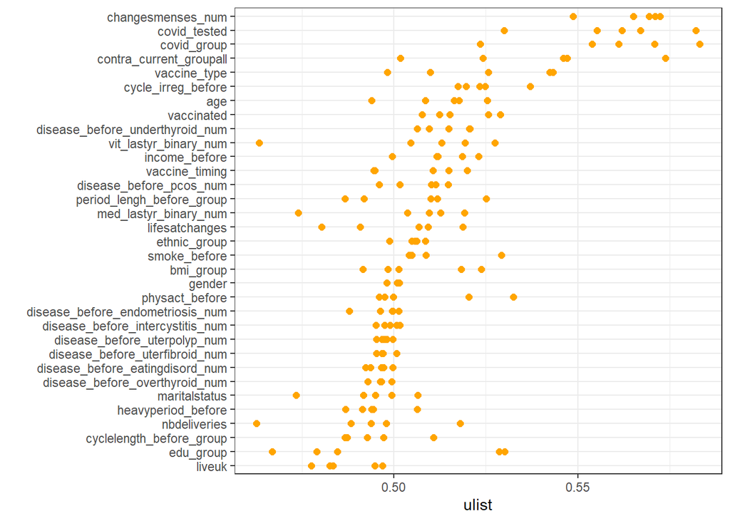

```r
aucplot
```

The plot displays for each variable, the AUC of the model with each of the 5 imputed datasets. Overall, AUCs are low and the univariable models have poor discriminative utility.

## Multivariable analyses

### Models and output tables

We take each exposure significant in the univariable models at q.value (e.g., FDR adjusted p.value) < 0.05 (Smoking, Menstrual cycles changes, COVID history and menstrual cycle changes over the last year). Based on DAGS (SI5), only COVID status and menstrual cycle changes should be adjusted for confounders.

#### Models 3 & 4. COVID status as exposure

True confounders are smoking and type of contraception

```r
# set global R options
pboptions(type = "timer", char = "=") # initialize progress bar

### Exposures -------------------------------------------------------------------

# set list of exposures to test
exposures <- c(
    Cs(
     covid_group,
     covid_tested

    )
)


 #model function - multivariate

models <- function(x) {
    lapply(multfin, function(y)
        glm(as.formula(
            paste0(
                "vaccine_changescycle_binary ~ smoke_before+contra_current_groupall+",
                x

            )
        ), data = y, model = TRUE,family=binomial())
    )
}


## run  models
models_test <- as.list(seq(1,length(exposures))) # create list to store model results
models_test <- pblapply(exposures, models)



### Pool -------------------------------------------------------------------
pool_tests <- as.list(seq(1,length(exposures))) # create list to store pool results


# run pool
for(j in seq_along(exposures)) {
    pool_tests[[j]] <- pool(models_test[[j]])
}



### p values under FDR-------------------------------------------------------------------

library(data.table)
smry1 <-lapply(pool_univariate,
             summary,
              conf.int = TRUE,
            conf.level = 0.95)
smry2 <-lapply(pool_tests,
             summary,
              conf.int = TRUE,
            conf.level = 0.95)

all_models <- rbindlist(c(smry1,smry2))





# this is the FDR p values
all_models$q.value <- p.adjust(all_models$p.value,method = "BH")



## Table with adjusted p values - covid tested  -------------------------------------------------------------------

library(kableExtra)


# subsetting the last model
all_models2<-all_models%>%
filter(row_number() >= (n() - 9)) %>%
filter (term!="(Intercept)")# to remove the intercept from the output

# have significant results in red
row<- which(all_models2$q.value<0.05) # to highlight in red those which are significant

# change names
names(all_models2)<-c("term","estimate","std.error","statistic","df","p.value","lowCI","highCI","q.value")

# create the table
# change row names

all_models2$term <- c("Past smoker","Current smoker","Combined","Copper IUD","Other","Progestin only","Sterilized","Self diagnosed +","Tested +")

# change column names
table<-all_models2%>% filter (term!="(Intercept)")%>%
  mutate(OR=exp(estimate))%>%
  mutate(ORConf.low=exp(lowCI))%>%
  mutate(ORConf.high=exp(highCI))%>%
  select(term,OR,ORConf.low,ORConf.high,statistic,df,p.value, q.value) %>%
  kbl(caption = "Multivariable model adjusted p-values",
      col.names = c("Variable",
                    "OR",
                    "95CI_Lower",
                    "95CI_Higher",
                    "Statistic",
                    "Df",
                    "P value",
                    "Q value")) %>%
  kable_paper(bootstrap_options = "striped", full_width = F
              )%>%
  row_spec(row=c(row), bold = T, color = "white", background = "#D7261E")%>%
  pack_rows("Smoking", 1,2) %>%
    pack_rows("Contraception", 3,7) %>%
  pack_rows("Covid Status", 8, 9) %>%
  kable_styling(full_width = T)


table%>%
   save_kable("TableSI_multivariable_COVID_tested.html")

table
```

Multivariable model adjusted p-values

| Variable | OR | 95CI_Lower | 95CI_Higher | Statistic | Df | P value | Q value |
| --- | --- | --- | --- | --- | --- | --- | --- |
| **Smoking** |  |  |  |  |  |  |  |
| Past smoker | 0.9614182 | 0.8090923 | 1.1424221 | -0.4471687 | 5008.15177 | 0.6547726 | 0.8201821 |
| Current smoker | 1.3258120 | 1.0594885 | 1.6590813 | 2.4656537 | 4906.73364 | 0.0137103 | 0.0329048 |
| **Contraception** |  |  |  |  |  |  |  |
| Combined | 0.5252841 | 0.3871160 | 0.7127666 | -4.1364619 | 2340.51882 | 0.0000365 | 0.0001217 |
| Copper IUD | 0.9188933 | 0.6454488 | 1.3081825 | -0.4694611 | 4915.50720 | 0.6387609 | 0.8201821 |
| Other | 1.7185406 | 1.1094951 | 2.6619149 | 2.4275665 | 1340.95630 | 0.0153314 | 0.0356698 |
| Progestin only | 1.1242524 | 0.9578779 | 1.3195246 | 1.4347674 | 1182.91415 | 0.1516177 | 0.2636830 |
| Sterilized | 0.7765336 | 0.4749115 | 1.2697194 | -1.0089024 | 1565.26657 | 0.3131774 | 0.4723890 |
| **Covid Status** |  |  |  |  |  |  |  |
| Self diagnosed + | 1.6888293 | 1.3010471 | 2.1921914 | 4.0182299 | 60.01967 | 0.0001659 | 0.0004524 |
| Tested + | 1.4750950 | 1.1712445 | 1.8577720 | 3.4347803 | 31.54380 | 0.0016807 | 0.0043845 |

```r
## Table with adjusted p values - long covid -------------------------------------------------------------------

library(kableExtra)
# subsetting the model we want
all_models3<-all_models%>%
filter(row_number() <= 110, row_number() >= 101) %>%
filter (term!="(Intercept)")# to remove the intercept from the output

# have significant results in red
row<- which(all_models3$q.value<0.05) # to highlight in red those which are significant

# change names
names(all_models3)<-c("term","estimate","std.error","statistic","df","p.value","lowCI","highCI","q.value")

# create the table
# change row names

all_models3$term <- c("Past smoker","Current smoker","Combined","Copper IUD","Other","Progestin only","Sterilized","Self diagnosed +","Tested +")

# change column names
table<-all_models3%>% filter (term!="(Intercept)")%>%
  mutate(OR=exp(estimate))%>%
  mutate(ORConf.low=exp(lowCI))%>%
  mutate(ORConf.high=exp(highCI))%>%
  select(term,OR,ORConf.low,ORConf.high,statistic,df,p.value, q.value) %>%
  kbl(caption = "Multivariable model adjusted p-values",
      col.names = c("Variable",
                    "OR",
                    "95CI_Lower",
                    "95CI_Higher",
                    "Statistic",
                    "Df",
                    "P value",
                    "Q value")) %>%
  kable_paper(bootstrap_options = "striped", full_width = F
              )%>%
  row_spec(row=c(row), bold = T, color = "white", background = "#D7261E")%>%
  pack_rows("Smoking", 1,2) %>%
    pack_rows("Contraception", 3,7) %>%
  pack_rows("Covid Status", 8, 9) %>%
  kable_styling(full_width = T)


table%>%
   save_kable("TableSI_multivariable_COVID_type.html")

table
```

Multivariable model adjusted p-values

| Variable | OR | 95CI_Lower | 95CI_Higher | Statistic | Df | P value | Q value |
| --- | --- | --- | --- | --- | --- | --- | --- |
| **Smoking** |  |  |  |  |  |  |  |
| Past smoker | 0.9635439 | 0.8110512 | 1.1447082 | -0.4225802 | 5040.78416 | 0.6726196 | 0.8224180 |
| Current smoker | 1.3269814 | 1.0604575 | 1.6604905 | 2.4737216 | 4899.59751 | 0.0134050 | 0.0328286 |
| **Contraception** |  |  |  |  |  |  |  |
| Combined | 0.5261439 | 0.3876665 | 0.7140864 | -4.1231942 | 2198.17388 | 0.0000388 | 0.0001257 |
| Copper IUD | 0.9241169 | 0.6492241 | 1.3154042 | -0.4382032 | 4863.96801 | 0.6612584 | 0.8201821 |
| Other | 1.7188447 | 1.1089533 | 2.6641583 | 2.4248582 | 1236.21924 | 0.0154569 | 0.0356698 |
| Progestin only | 1.1247096 | 0.9582913 | 1.3200284 | 1.4399685 | 1186.26107 | 0.1501402 | 0.2636830 |
| Sterilized | 0.7745271 | 0.4738141 | 1.2660921 | -1.0197671 | 1613.16992 | 0.3079918 | 0.4723890 |
| **Covid Status** |  |  |  |  |  |  |  |
| Self diagnosed + | 1.5760569 | 1.2628214 | 1.9669888 | 4.0291979 | 946.52886 | 0.0000605 | 0.0001754 |
| Tested + | 1.5473127 | 1.2632613 | 1.8952347 | 4.2729708 | 94.53027 | 0.0000460 | 0.0001402 |

#### Models 5 & 6 Menstrual cycle changes over the last year as exposure

```r
# set global R options
pboptions(type = "timer", char = "=") # initialize progress bar

### Exposures -------------------------------------------------------------------

# set list of exposures to test
exposures <- c(
    Cs(
     covid_group,
     covid_tested

    )
)


 #model function - multivariate

models <- function(x) {
    lapply(multfin, function(y)
        glm(as.formula(
            paste0(
                "vaccine_changescycle_binary ~ smoke_before+contra_current_groupall+changesmenses_num+",
                x

            )
        ), data = y, model = TRUE,family=binomial())
    )
}


## run  models
models_test <- as.list(seq(1,length(exposures))) # create list to store model results
models_test <- pblapply(exposures, models)



### Pool -------------------------------------------------------------------
pool_tests <- as.list(seq(1,length(exposures))) # create list to store pool results


# run pool
for(j in seq_along(exposures)) {
    pool_tests[[j]] <- pool(models_test[[j]])
}



### p values under FDR-------------------------------------------------------------------

library(data.table)
smry1 <-lapply(pool_univariate,
             summary,
              conf.int = TRUE,
            conf.level = 0.95)
smry2 <-lapply(pool_tests,
             summary,
              conf.int = TRUE,
            conf.level = 0.95)

all_models <- rbindlist(c(smry1,smry2))





# this is the FDR p values
all_models$q.value <- p.adjust(all_models$p.value,method = "BH")



## Table with adjusted p values - covid tested  -------------------------------------------------------------------

library(kableExtra)


# subsetting the last model
all_models2<-all_models%>%
filter(row_number() >= (n() - 10)) %>%
filter (term!="(Intercept)")# to remove the intercept from the output

# have significant results in red
row<- which(all_models2$q.value<0.05) # to highlight in red those which are significant

# change names
names(all_models2)<-c("term","estimate","std.error","statistic","df","p.value","lowCI","highCI","q.value")

# create the table
# change row names

all_models2$term <- c("Past smoker","Current smoker","Combined","Copper IUD","Other","Progestin only", "Sterilized","Prior changes in menstrual cycles","Self diagnosed +","Tested +")

# change column names
table<-all_models2%>% filter (term!="(Intercept)")%>%
  mutate(OR=exp(estimate))%>%
  mutate(ORConf.low=exp(lowCI))%>%
  mutate(ORConf.high=exp(highCI))%>%
  select(term,OR,ORConf.low,ORConf.high,statistic,df,p.value, q.value) %>%
  kbl(caption = "Multivariable model adjusted p-values",
      col.names = c("Variable",
                    "OR",
                    "95CI_Lower",
                    "95CI_Higher",
                    "Statistic",
                    "Df",
                    "P value",
                    "Q value")) %>%
  kable_paper(bootstrap_options = "striped", full_width = F
              )%>%
  row_spec(row=c(row), bold = T, color = "white", background = "#D7261E")%>%
  pack_rows("Smoking", 1,2) %>%
    pack_rows("Contraception", 3,7) %>%
      pack_rows("Prior changes in menses", 8,8) %>%
  pack_rows("Covid Status", 9, 10) %>%
  kable_styling(full_width = T)


table%>%
   save_kable("TableSI_multivariable_menstruation.html")

table
```

Multivariable model adjusted p-values

| Variable | OR | 95CI_Lower | 95CI_Higher | Statistic | Df | P value | Q value |
| --- | --- | --- | --- | --- | --- | --- | --- |
| **Smoking** |  |  |  |  |  |  |  |
| Past smoker | 0.9419146 | 0.7920296 | 1.1201641 | -0.6768832 | 4895.18857 | 0.4985120 | 0.6683348 |
| Current smoker | 1.2676139 | 1.0116240 | 1.5883815 | 2.0608800 | 4969.07248 | 0.0393664 | 0.0822614 |
| **Contraception** |  |  |  |  |  |  |  |
| Combined | 0.5329728 | 0.3925827 | 0.7235673 | -4.0364296 | 2283.20009 | 0.0000561 | 0.0001800 |
| Copper IUD | 0.9269245 | 0.6503880 | 1.3210408 | -0.4198829 | 4798.87974 | 0.6745898 | 0.8277637 |
| Other | 1.7101610 | 1.1018522 | 2.6543039 | 2.3946556 | 1291.86242 | 0.0167778 | 0.0395330 |
| Progestin only | 1.1179560 | 0.9531641 | 1.3112388 | 1.3713770 | 1719.90969 | 0.1704364 | 0.2928625 |
| Sterilized | 0.7588015 | 0.4636823 | 1.2417550 | -1.0991563 | 1639.32118 | 0.2718613 | 0.4252189 |
| **Prior changes in menses** |  |  |  |  |  |  |  |
| Prior changes in menstrual cycles | 1.1686351 | 1.0741279 | 1.2714575 | 3.6924089 | 63.44758 | 0.0004641 | 0.0012309 |
| **Covid Status** |  |  |  |  |  |  |  |
| Self diagnosed + | 1.6406053 | 1.2634129 | 2.1304087 | 3.7887969 | 61.38765 | 0.0003472 | 0.0009414 |
| Tested + | 1.4400104 | 1.1355346 | 1.8261267 | 3.1466383 | 27.57297 | 0.0039387 | 0.0098067 |

```r
## Table with adjusted p values - long covid -------------------------------------------------------------------

library(kableExtra)
# subsetting the model we want
all_models3<-all_models%>%
filter(row_number() <= 111, row_number() >= 101) %>%
filter (term!="(Intercept)")# to remove the intercept from the output

# have significant results in red
row<- which(all_models3$q.value<0.05) # to highlight in red those which are significant

# change names
names(all_models3)<-c("term","estimate","std.error","statistic","df","p.value","lowCI","highCI","q.value")

# create the table
# change row names

all_models3$term <- c("Past smoker","Current smoker","Combined","Copper IUD","Other","Progestin only", "Sterilization", "Prior changes in menstrual cycles","COVID + long","COVID + short")

# change column names
table<-all_models3%>% filter (term!="(Intercept)")%>%
  mutate(OR=exp(estimate))%>%
  mutate(ORConf.low=exp(lowCI))%>%
  mutate(ORConf.high=exp(highCI))%>%
  select(term,OR,ORConf.low,ORConf.high,statistic,df,p.value, q.value) %>%
  kbl(caption = "Multivariable model adjusted p-values",
      col.names = c("Variable",
                    "OR",
                    "95CI_Lower",
                    "95CI_Higher",
                    "Statistic",
                    "Df",
                    "P value",
                    "Q value")) %>%
  kable_paper(bootstrap_options = "striped", full_width = F
              )%>%
  row_spec(row=c(row), bold = T, color = "white", background = "#D7261E")%>%
  pack_rows("Smoking", 1,2) %>%
    pack_rows("Contraception", 3,7) %>%
      pack_rows("Prior changes in menses", 8,8) %>%
  pack_rows("Covid Status", 9, 10) %>%
  kable_styling(full_width = T)


table%>%
   save_kable("TableSI8_multivariable_Menstrualchanges_acute_long.html")

table
```

Multivariable model adjusted p-values

| Variable | OR | 95CI_Lower | 95CI_Higher | Statistic | Df | P value | Q value |
| --- | --- | --- | --- | --- | --- | --- | --- |
| **Smoking** |  |  |  |  |  |  |  |
| Past smoker | 0.9439307 | 0.7939449 | 1.122251 | -0.6537391 | 4998.11896 | 0.5133100 | 0.6806937 |
| Current smoker | 1.2686414 | 1.0124290 | 1.589693 | 2.0677881 | 4938.22611 | 0.0387119 | 0.0822614 |
| **Contraception** |  |  |  |  |  |  |  |
| Combined | 0.5338088 | 0.3931189 | 0.724849 | -4.0238411 | 2151.65539 | 0.0000592 | 0.0001853 |
| Copper IUD | 0.9320645 | 0.6540787 | 1.328196 | -0.3894272 | 4718.64104 | 0.6969777 | 0.8336400 |
| Other | 1.7111198 | 1.1016588 | 2.657748 | 2.3933572 | 1182.76486 | 0.0168501 | 0.0395330 |
| Progestin only | 1.1184264 | 0.9535675 | 1.311787 | 1.3765780 | 1710.73027 | 0.1688229 | 0.2928625 |
| Sterilization | 0.7574321 | 0.4629425 | 1.239254 | -1.1068099 | 1661.07082 | 0.2685364 | 0.4252189 |
| **Prior changes in menses** |  |  |  |  |  |  |  |
| Prior changes in menstrual cycles | 1.1686342 | 1.0739911 | 1.271618 | 3.6881127 | 62.35298 | 0.0004760 | 0.0012355 |
| **Covid Status** |  |  |  |  |  |  |  |
| COVID + long | 1.5240898 | 1.2194479 | 1.904837 | 3.7087838 | 884.28535 | 0.0002212 | 0.0006134 |
| COVID + short | 1.5155749 | 1.2376365 | 1.855930 | 4.0717601 | 100.21824 | 0.0000933 | 0.0002711 |

### AUC multivariable models

```r
library(pROC)
#make this example reproducible
set.seed(1)
#Use 70% of dataset as training set and remaining 30% as testing set
train_list<-list()
test_list<-list()
sample_list<-list()

 for (i in (1:5)){
sample_list[[i]] <-  sample(c(TRUE, FALSE), nrow(multfin[[i]]), replace=TRUE, prob=c(0.7,0.3))
 }
#
 for (i in (1:5)){
train_list[[i]] <- multfin[[i]][sample_list[[i]], ]
test_list[[i]] <- multfin[[i]][!sample_list[[i]], ]
}


#
exposures <- c(
    Cs(
      changesmenses_num
    )
)

## model function
modelstrain <- function(x) {
    lapply(train_list, function(y)
        glm(as.formula(
            paste0(
                "vaccine_changescycle_binary ~  smoke_before+contra_current_groupall+covid_tested+ ",
                x

            )
        ), data = y, model=TRUE, family=binomial())
    )
}


## run logistic models
model_list <- as.list(seq(1,length(exposures))) # create list to store model results
model_list <- pblapply(exposures, modelstrain)



# Calculate probability of default for each individual in test dataset
predicted_list<-list()
z<-0

for (i in (1:length(exposures))){
  for (j in (1:5)){
    z<-z+1
predicted_list[[z]] <- predict(model_list[[i]][[j]], test_list[[j]], type="response")
  }
}


# Calculate AUC
z<-0
auc_list<-list()
for (i in (1:length(exposures))){
for (i in (1:5)){
     z<-z+1
auc_list[[z]]<-auc(test_list[[i]]$vaccine_changescycle_binary, predicted_list[[z]] )
}
}

# Matrix of AUC
# Unlist
ulist<-unlist(auc_list)
# from 0.55 to 0.61


# Create vector of names
names<-NULL
for (i in (1:1)){
newnames<-c(rep(exposures[i],5))
names<-c(names,newnames)
}

matauc<-as.data.frame(cbind(names,as.numeric(ulist)))

# group means
library(plyr)
mu <- ddply(matauc, "names", summarise, mean = mean(ulist))
newdat<-tapply(ulist, names,max,na.rm=T)


# load the library
library(forcats)

# Reorder following the value of another column:
aucplot<-matauc %>%
  mutate(names = fct_reorder(names, ulist)) %>%
  ggplot( aes(x=names, y=ulist))+
    geom_point( size=2, color="orange") +
    coord_flip() +
    xlab("") +
    theme_bw()

pdf(file="AUC_multivariable_models.pdf")
aucplot
dev.off()
```

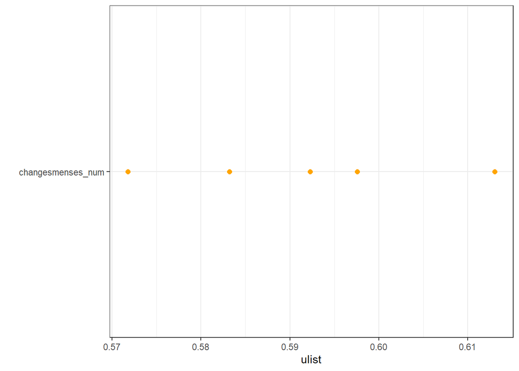

```r
aucplot
```

For the full model, AUCs vary between 0.57 and 0.61 depending on which imputed dataset is used.

# 4. Plot models

#### Plot OR

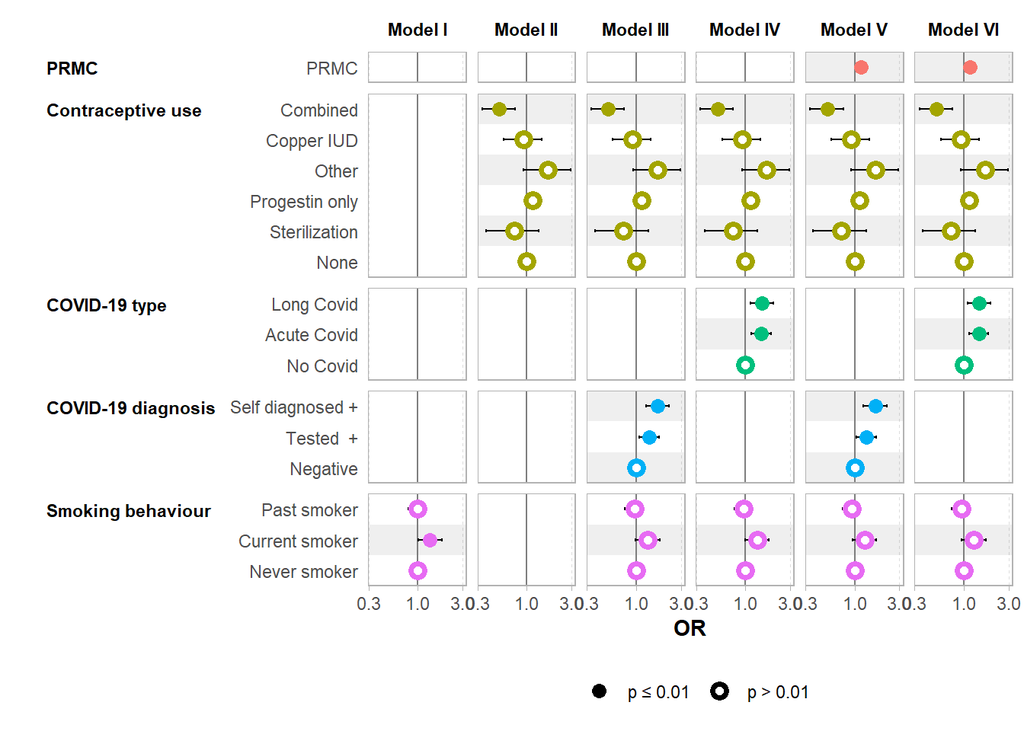

```r
# REname levels
levels(multfin[[1]]$covid_group)[1]<- "No Covid"
levels(multfin[[1]]$covid_group)[2]<- "Long Covid"
levels(multfin[[1]]$covid_group)[3]<- "Acute Covid"


# Models

# Model I
modelsmoking<-glm(vaccine_changescycle_binary ~    smoke_before, data = multfin[[1]], family=binomial, model = TRUE)
#
modelchangemense<-glm(vaccine_changescycle_binary ~     smoke_before+contra_current_groupall+covid_tested+changesmenses_num, data = multfin[[1]], family=binomial, model = TRUE)
# Model II
modelchangemensegroup<-glm(vaccine_changescycle_binary ~     smoke_before+contra_current_groupall+covid_group+changesmenses_num, data = multfin[[1]], family=binomial, model = TRUE)
# Model III
modeltested<-glm(vaccine_changescycle_binary ~    smoke_before+contra_current_groupall+covid_tested, data = multfin[[1]], family=binomial, model = TRUE)
# Model IV
modelgroup<-glm(vaccine_changescycle_binary ~    smoke_before+contra_current_groupall+covid_group, data = multfin[[1]], family=binomial, model = TRUE)
# Model V
modelcontra<-glm(vaccine_changescycle_binary ~    contra_current_groupall, data = multfin[[1]], family=binomial, model = TRUE)


# List of models

models <- list( "Model I" = modelsmoking, "Model II" = modelcontra,"Model III" = modeltested, "Model IV" = modelgroup, "Model V" = modelchangemense ,"Model VI" = modelchangemensegroup)


# Plot compare models

plot_OR<-ggcoef_compare(models,
                    type = c("faceted"),
                    conf.level = 0.99,
                    exponentiate = TRUE,
                    add_reference_rows = TRUE,
                    variable_labels = c(
                    smoke_before="Smoking behaviour",
                    contra_current_groupall= "Contraceptive use",
                    covid_tested= "COVID-19 diagnosis",
                    covid_group= "COVID-19 type",
                    changesmenses_num= "PRMC"))



# Save plot

ggsave(filename="Figure3.pdf", width = 30,  height = 20, units = "cm")


plot_OR
```

#### Plot predicted probability

```r
# set up
trellis.device()
trellis.par.set(list(axis.text = list(font = 1, cex=1)))
trellis.par.set(list(par.ylab.text = list(font = 1, cex=1)))
trellis.par.set(list(par.xlab.text = list(font = 1, cex=1)))
trellis.par.set(list(par.main.text = list(font = 1, cex=1)))
trellis.par.set(grid.pars = list(fontfamily = "serif"))


## Plot effect of contraceptive use

a<-plot(Effect("contra_current_groupall",modelcontra),
    lines = list(multiline = FALSE),
     lty=0,
     lwd=6,
     ylim=c(-3,-0.3),
     lattice=list(strip=list(factor.names=FALSE)),
     confint = list(style = "auto"),
     response="",
     xlab="Contraceptive use",
     ylab= "Predicted probability",
     main="")

## Plot effect covid_tested


b<-plot(Effect("covid_tested",modeltested),
     lines = list(multiline = T),
     lty=0,
     lwd=6,
     ylim=c(-3,-0.3),
     lattice=list(strip=list(factor.names=FALSE)),
     confint = list(style = "auto"),
     response="",
     xlab="COVID Status",
     ylab= "Predicted probability",
     main="")

## Plot effect covid_group

c<-plot(Effect("covid_group",modelgroup),
     lines = list(multiline = T),
     lty=0,
     lwd=6,
     ylim=c(-3,-0.3),
     lattice=list(strip=list(factor.names=FALSE)),
     confint = list(style = "auto"),
     response="",
     xlab="COVID Status",
     ylab= "Predicted probability",
     main="")

## Plot changes menses

d<-plot(Effect("changesmenses_num",modelchangemense),
     lines = list(multiline = T),
     lty=0,
     lwd=6,
     ylim=c(-3,-0.3),
     symbols=TRUE,
     lattice=list(strip=list(factor.names=FALSE)),
     confint = list(style = "auto"),
     response="",
     xlab="Pandemic-related menstrual changes",
     ylab= "Predicted probability",
     main="")


# grid arrange

plotpredictedvalues<-grid.arrange(a,b,c,d,ncol=2)
plotpredictedvalues
```

```r
# save
pdf(file='Figure2.pdf', width=15,height=8) # Open PDF device with specific file name
grid.arrange(a,b,c,d,ncol=2)
dev.off() # Turn the PDF device off
```

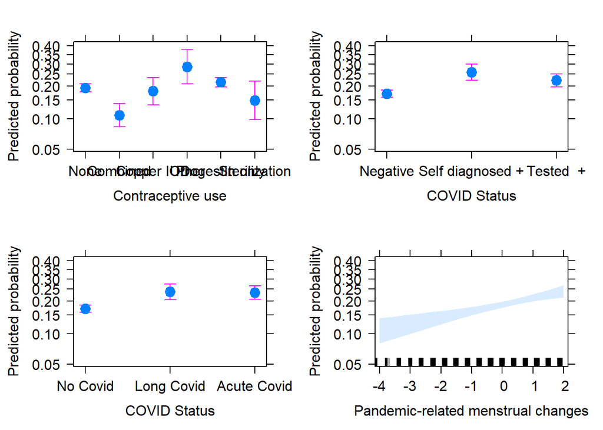

```r
grid.arrange(a,b,c,d,ncol=2)
```

# 5. Analysis on complete cases

```r
# manipulation variables
levels(dataor$smoke_before)[3]<-"Current Smoker"
levels(dataor$smoke_before)[4]<-"Current Smoker"
dataor$contra_current_groupall<-as.factor(dataor$contra_current_groupall)
dataor$contra_current_groupall<-relevel(dataor$contra_current_groupall, ref = "None")


## models--------------------------------------------------------
model1<-glm(vaccine_changescycle_binary ~ smoke_before, data =dataor, family=binomial, model = TRUE)

## model 2----------------------------------------------------

model2<-glm(vaccine_changescycle_binary ~ contra_current_groupall, data =dataor, family=binomial, model = TRUE)

## model 3----------------------------------------------------

model3<-glm(vaccine_changescycle_binary ~   smoke_before+contra_current_groupall+covid_tested, data =dataor, family=binomial, model = TRUE)

## model 4----------------------------------------------------

model4<-glm(vaccine_changescycle_binary ~    smoke_before+contra_current_groupall+covid_group, data =dataor, family=binomial, model = TRUE)

## model 5----------------------------------------------------

model5<-glm(vaccine_changescycle_binary ~    smoke_before+contra_current_groupall+ changesmenses_num+covid_tested, data =dataor, family=binomial, model = TRUE)

## model 5----------------------------------------------------

model6<-glm(vaccine_changescycle_binary ~   smoke_before+contra_current_groupall+ changesmenses_num+covid_group, data =dataor, family=binomial, model = TRUE)


### model summary

library(modelsummary)

# plot
msuni<-modelsummary(list(model1,model2,model3,model4,model5,model6),
                    coef_rename=c(

                                  "smoke_beforeNo, but I have smoked in the past"="Past smokers",
                                  "smoke_beforeCurrent Smoker"="Current smokers",
                                  "contra_current_groupallCopper IUD"="Copper IUD",
                                  "contra_current_groupallCombined estrogen-progestin"="Combined",
                                  "contra_current_groupallProgestin only"= "Progestin only",
                                  "contra_current_groupallOther"= "Other contraceptives",
                               "contra_current_groupallSterilization"= "Sterilization",


                                  "changesmenses_num"="Menstrual cycle changes over the last year",

                                  "covid_testedSelf diagnosed +"= "COVID self-diagnosed positive",
                                  "covid_testedTested  +"="COVID tested positive",

                               "covid_groupCOVID + long"="Long Covid",
                                "covid_groupCOVID + short"="Acute Covid"),


                    stars = c('*' = 0.05,'**' = 0.01,'***' = 0.001),
                    exponentiate = TRUE,estimate = "{estimate}{stars} [{conf.low}, {conf.high}]",
                    statistic = NULL ,
                    gof_omit = ".*",title = 'Risk factors for vaccine related changes in menstrual cycles using complete cases',
                    coef_omit = "Intercept",
                    output = "kableExtra")

# save

save_kable(msuni, file="TableSIcompletecases.html")
msuni
```

Risk factors for vaccine related changes in menstrual cycles using complete cases

|  | Model 1 | Model 2 | Model 3 | Model 4 | Model 5 | Model 6 |
| --- | --- | --- | --- | --- | --- | --- |
| Past smokers | 1.008 [0.848, 1.194] |  | 0.898 [0.722, 1.111] | 0.951 [0.770, 1.170] | 0.868 [0.683, 1.097] | 0.912 [0.723, 1.146] |
| Current smokers | 1.358** [1.084, 1.691] |  | 1.420* [1.081, 1.850] | 1.393* [1.062, 1.810] | 1.424* [1.050, 1.912] | 1.365* [1.009, 1.826] |
| Combined |  | 0.444*** [0.314, 0.613] | 0.382*** [0.255, 0.554] | 0.384*** [0.258, 0.553] | 0.414*** [0.269, 0.613] | 0.422*** [0.277, 0.621] |
| Copper IUD |  | 0.933 [0.647, 1.314] | 0.861 [0.570, 1.263] | 0.850 [0.566, 1.241] | 1.086 [0.706, 1.623] | 1.051 [0.685, 1.568] |
| Other contraceptives |  | 1.569 [0.944, 2.523] | 1.411 [0.785, 2.413] | 1.524 [0.870, 2.559] | 1.518 [0.803, 2.716] | 1.660 [0.907, 2.903] |
| Progestin only |  | 0.882 [0.717, 1.080] | 0.904 [0.723, 1.125] | 0.880 [0.705, 1.093] | 0.906 [0.704, 1.158] | 0.886 [0.690, 1.130] |
| Sterilization |  | 0.769 [0.460, 1.224] | 0.893 [0.523, 1.449] | 0.865 [0.514, 1.388] | 0.828 [0.451, 1.424] | 0.788 [0.431, 1.349] |
| COVID self-diagnosed positive |  |  | 2.040*** [1.544, 2.673] |  | 2.190*** [1.621, 2.933] |  |
| COVID tested positive |  |  | 1.638*** [1.301, 2.051] |  | 1.613*** [1.248, 2.072] |  |
| Long Covid |  |  |  | 1.849*** [1.424, 2.384] |  | 1.867*** [1.400, 2.468] |
| Acute Covid |  |  |  | 1.920*** [1.539, 2.385] |  | 1.957*** [1.534, 2.485] |
| Menstrual cycle changes over the last year |  |  |  |  | 1.093*** [1.053, 1.135] | 1.088*** [1.049, 1.129] |